# Linear Regression

OBJECTIVE:

Here I will try to determine whether a basketball team’s stats can help predict how much they will win or lose by in a game.

We will load the libraries

```r
#LOAD DATA AND LIBRARIES

#libraries
library(class)
library(gmodels)
library(Amelia)
library(ISLR)
library(caret)
library(readxl)
library(pROC)
library(lattice)
library(ggplot2)
library(dplyr)
library(e1071)
library(corrplot)
library(kknn)
library(ggplot2)
library(multiROC)
library(MLeval)
library(AppliedPredictiveModeling)
library(corrplot)
library(Hmisc)
library(dplyr)
library( ggfortify)
library (magrittr)
library (car)
library (broom)
library (psych)
```

We have to load and fix the data to our purposes by removing unnecessary factors such as the date of the game, team name, etc. We will also seperate out some of the columns to help us try out different combinations manually for the linear regression model.

```r
# GET SPECIFIC DATA

file <- 0 # the file we will be loading
all_data <- 0 # subset of file with columns that will actually be used,
              # and are complete cases + win_difference
home_stats <- 0 # subset of all_data containing only home team stats (except points)
away_stats <- 0 # subset of all_data containing only away team stats (except points)
win_difference <- 0 # home teams score - away team score
home_team_wins <- 0 # basically a binary of win_difference (factored)

file <- read.csv("games.csv", header=TRUE, stringsAsFactors = FALSE) #load data
all_data <- file[complete.cases(c("FG_PCT_home","FT_PCT_home","FG3_PCT_home","AST_home",
                                  "REB_home","HOME_TEAM_WINS","PTS_home","PTS_away",
                                  "FG_PCT_away","FT_PCT_away","FG3_PCT_away",
                                  "AST_away",   "REB_away")), ]
all_data$win_difference=(all_data$PTS_home-all_data$PTS_away)
home_stats <- all_data[c("FG_PCT_home","FT_PCT_home","FG3_PCT_home","AST_home","REB_home")]
away_stats <- all_data[c("FG_PCT_away","FT_PCT_away","FG3_PCT_away","AST_away","REB_away")]
win_difference <- all_data$win_difference
home_team_wins <- all_data$HOME_TEAM_WINS
all_data$HOME_TEAM_WINS<-factor(all_data$HOME_TEAM_WINS,levels=c(0,1),labels=c("W","L"))

lm_test_1 <- 0 # lm model test using home_stats and win difference
lm_test_2 <- 0 # lm model test using home_stats and win difference and home_team_wins
lm_test_3 <- 0 # lm model test using home_stats and away stats and win difference and
                                                                      # home team wins
lm_test_4 <- 0 # lm model test using home_stats and away stats

lm_test_1 <- lm(win_difference ~ . ,data=cbind(home_stats,win_difference))
lm_test_2 <- lm(win_difference ~ . ,data=cbind(home_stats,win_difference,home_team_wins))
lm_test_3 <- lm(win_difference ~ . ,data=cbind(home_stats, away_stats, win_difference,
                                               home_team_wins))
lm_test_4 <- lm(win_difference ~ . ,data=cbind(home_stats, away_stats, win_difference))

summary (lm_test_1)
```

```
##
## Call:
## lm(formula = win_difference ~ ., data = cbind(home_stats, win_difference))
##
## Residuals:
##     Min      1Q  Median      3Q     Max
## -39.902  -6.264   0.083   6.302  40.629
##
## Coefficients:
##                Estimate Std. Error  t value Pr(>|t|)
## (Intercept)  -1.108e+02  8.832e-01 -125.471   <2e-16 ***
## FG_PCT_home   1.222e+02  1.430e+00   85.487   <2e-16 ***
## FT_PCT_home   1.519e+01  6.205e-01   24.481   <2e-16 ***
## FG3_PCT_home  1.731e+01  6.098e-01   28.393   <2e-16 ***
## AST_home      1.281e-01  1.494e-02    8.572   <2e-16 ***
## REB_home      8.584e-01  9.853e-03   87.121   <2e-16 ***
## ---
## Signif. codes:  0 '***' 0.001 '**' 0.01 '*' 0.05 '.' 0.1 ' ' 1
##
## Residual standard error: 9.422 on 22939 degrees of freedom
##   (99 observations deleted due to missingness)
## Multiple R-squared:  0.4962, Adjusted R-squared:  0.496
## F-statistic:  4518 on 5 and 22939 DF,  p-value: < 2.2e-16
```

```r
summary (lm_test_2)
```

```
##
## Call:
## lm(formula = win_difference ~ ., data = cbind(home_stats, win_difference,
##     home_team_wins))
##
## Residuals:
##     Min      1Q  Median      3Q     Max
## -39.467  -4.523  -0.167   4.271  40.677
##
## Coefficients:
##                  Estimate Std. Error t value Pr(>|t|)
## (Intercept)    -65.141256   0.714069  -91.22   <2e-16 ***
## FG_PCT_home     61.401139   1.118615   54.89   <2e-16 ***
## FT_PCT_home      7.292021   0.452819   16.10   <2e-16 ***
## FG3_PCT_home     8.353563   0.446123   18.73   <2e-16 ***
## AST_home         0.122674   0.010824   11.33   <2e-16 ***
## REB_home         0.441924   0.007701   57.39   <2e-16 ***
## home_team_wins  16.068336   0.111495  144.12   <2e-16 ***
## ---
## Signif. codes:  0 '***' 0.001 '**' 0.01 '*' 0.05 '.' 0.1 ' ' 1
##
## Residual standard error: 6.826 on 22938 degrees of freedom
##   (99 observations deleted due to missingness)
## Multiple R-squared:  0.7356, Adjusted R-squared:  0.7355
## F-statistic: 1.064e+04 on 6 and 22938 DF,  p-value: < 2.2e-16
```

```r
summary (lm_test_3) #lm_test_3 seems to be the best model to manually come up with
```

```
##
## Call:
## lm(formula = win_difference ~ ., data = cbind(home_stats, away_stats,
##     win_difference, home_team_wins))
##
## Residuals:
##     Min      1Q  Median      3Q     Max
## -29.707  -3.732  -0.104   3.585  36.017
##
## Coefficients:
##                  Estimate Std. Error t value Pr(>|t|)
## (Intercept)     -4.180700   1.055516  -3.961 7.49e-05 ***
## FG_PCT_home     55.772669   1.028423  54.231  < 2e-16 ***
## FT_PCT_home      9.384421   0.379683  24.716  < 2e-16 ***
## FG3_PCT_home     9.622607   0.370399  25.979  < 2e-16 ***
## AST_home         0.316433   0.009356  33.821  < 2e-16 ***
## REB_home         0.228502   0.007122  32.085  < 2e-16 ***
## FG_PCT_away    -58.666712   1.029077 -57.009  < 2e-16 ***
## FT_PCT_away    -10.128084   0.369144 -27.437  < 2e-16 ***
## FG3_PCT_away    -9.107453   0.372979 -24.418  < 2e-16 ***
## AST_away        -0.275058   0.009202 -29.892  < 2e-16 ***
## REB_away        -0.230170   0.007137 -32.250  < 2e-16 ***
## home_team_wins  11.011261   0.105086 104.783  < 2e-16 ***
## ---
## Signif. codes:  0 '***' 0.001 '**' 0.01 '*' 0.05 '.' 0.1 ' ' 1
##
## Residual standard error: 5.662 on 22933 degrees of freedom
##   (99 observations deleted due to missingness)
## Multiple R-squared:  0.8181, Adjusted R-squared:  0.818
## F-statistic:  9376 on 11 and 22933 DF,  p-value: < 2.2e-16
```

```r
summary (lm_test_4)
```

```
##
## Call:
## lm(formula = win_difference ~ ., data = cbind(home_stats, away_stats,
##     win_difference))
##
## Residuals:
##     Min      1Q  Median      3Q     Max
## -28.327  -4.595   0.007   4.554  31.856
##
## Coefficients:
##                Estimate Std. Error t value Pr(>|t|)
## (Intercept)    2.178754   1.281403    1.70   0.0891 .
## FG_PCT_home   85.582247   1.201781   71.21   <2e-16 ***
## FT_PCT_home   14.604622   0.457710   31.91   <2e-16 ***
## FG3_PCT_home  15.042803   0.445998   33.73   <2e-16 ***
## AST_home       0.407139   0.011328   35.94   <2e-16 ***
## REB_home       0.336920   0.008568   39.32   <2e-16 ***
## FG_PCT_away  -89.809845   1.198048  -74.96   <2e-16 ***
## FT_PCT_away  -15.031158   0.445265  -33.76   <2e-16 ***
## FG3_PCT_away -14.518706   0.449181  -32.32   <2e-16 ***
## AST_away      -0.363991   0.011142  -32.67   <2e-16 ***
## REB_away      -0.342370   0.008581  -39.90   <2e-16 ***
## ---
## Signif. codes:  0 '***' 0.001 '**' 0.01 '*' 0.05 '.' 0.1 ' ' 1
##
## Residual standard error: 6.885 on 22934 degrees of freedom
##   (99 observations deleted due to missingness)
## Multiple R-squared:  0.731,  Adjusted R-squared:  0.7309
## F-statistic:  6232 on 10 and 22934 DF,  p-value: < 2.2e-16
```

From these results, it seems like the 1st combination was the worst with an adjusted R-squared value of 0.496, while 3rd combination of features we tried had the best predictiton rate, with an adjusted R-squared of 0.818, so we will try to improve upon this model. Below we will try AIC to test to see if we can find a better model from these features. We will also test for multicollinear features.

```r
step_model <- 0 #uses AIC to check for a better model

step_model <- MASS::stepAIC(lm_test_3, direction="both", trace=FALSE)
summary (step_model)
```

```
##
## Call:
## lm(formula = win_difference ~ FG_PCT_home + FT_PCT_home + FG3_PCT_home +
##     AST_home + REB_home + FG_PCT_away + FT_PCT_away + FG3_PCT_away +
##     AST_away + REB_away + home_team_wins, data = cbind(home_stats,
##     away_stats, win_difference, home_team_wins))
##
## Residuals:
##     Min      1Q  Median      3Q     Max
## -29.707  -3.732  -0.104   3.585  36.017
##
## Coefficients:
##                  Estimate Std. Error t value Pr(>|t|)
## (Intercept)     -4.180700   1.055516  -3.961 7.49e-05 ***
## FG_PCT_home     55.772669   1.028423  54.231  < 2e-16 ***
## FT_PCT_home      9.384421   0.379683  24.716  < 2e-16 ***
## FG3_PCT_home     9.622607   0.370399  25.979  < 2e-16 ***
## AST_home         0.316433   0.009356  33.821  < 2e-16 ***
## REB_home         0.228502   0.007122  32.085  < 2e-16 ***
## FG_PCT_away    -58.666712   1.029077 -57.009  < 2e-16 ***
## FT_PCT_away    -10.128084   0.369144 -27.437  < 2e-16 ***
## FG3_PCT_away    -9.107453   0.372979 -24.418  < 2e-16 ***
## AST_away        -0.275058   0.009202 -29.892  < 2e-16 ***
## REB_away        -0.230170   0.007137 -32.250  < 2e-16 ***
## home_team_wins  11.011261   0.105086 104.783  < 2e-16 ***
## ---
## Signif. codes:  0 '***' 0.001 '**' 0.01 '*' 0.05 '.' 0.1 ' ' 1
##
## Residual standard error: 5.662 on 22933 degrees of freedom
##   (99 observations deleted due to missingness)
## Multiple R-squared:  0.8181, Adjusted R-squared:  0.818
## F-statistic:  9376 on 11 and 22933 DF,  p-value: < 2.2e-16
```

```r
step_model.diagnostics <- augment(step_model)
head(step_model.diagnostics)
```

```
## # A tibble: 6 x 20
##   .rownames win_difference FG_PCT_home FT_PCT_home FG3_PCT_home AST_home
##   <chr>              <dbl>       <dbl>       <dbl>        <dbl>    <dbl>
## 1 1                    -12       0.461       0.643        0.290       24
## 2 2                     -5       0.565       0.667        0.514       34
## 3 3                     -9       0.458       0.727        0.206       28
## 4 4                     -8       0.506       0.828        0.409       28
## 5 5                     -8       0.5         0.905        0.4         22
## 6 6                     22       0.483       0.857        0.441       28
## # ... with 14 more variables: REB_home <dbl>, FG_PCT_away <dbl>,
## #   FT_PCT_away <dbl>, FG3_PCT_away <dbl>, AST_away <dbl>, REB_away <dbl>,
## #   home_team_wins <int>, .fitted <dbl>, .se.fit <dbl>, .resid <dbl>,
## #   .hat <dbl>, .sigma <dbl>, .cooksd <dbl>, .std.resid <dbl>
```

```r
lm_test_3$call
```

```
## lm(formula = win_difference ~ ., data = cbind(home_stats, away_stats,
##     win_difference, home_team_wins))
```

```r
step_model$call
```

```
## lm(formula = win_difference ~ FG_PCT_home + FT_PCT_home + FG3_PCT_home +
##     AST_home + REB_home + FG_PCT_away + FT_PCT_away + FG3_PCT_away +
##     AST_away + REB_away + home_team_wins, data = cbind(home_stats,
##     away_stats, win_difference, home_team_wins))
```

```r
vif(step_model) %>%
  knitr::kable()
```

|  | x |
| --- | --- |
| FG_PCT_home | 2.439209 |
| FT_PCT_home | 1.040895 |
| FG3_PCT_home | 1.294323 |
| AST_home | 1.658600 |
| REB_home | 1.576319 |
| FG_PCT_away | 2.343468 |
| FT_PCT_away | 1.037088 |
| FG3_PCT_away | 1.269442 |
| AST_away | 1.561121 |
| REB_away | 1.535653 |
| home_team_wins | 1.904595 |

As we can see from above, the results are the same, so the model was not improved through AIC. It also doesn’t seem like there are multicollinear features based on the results of the vif test. So below we will generate graphs and look at them to try to figure out different techniques we can try to improve the results

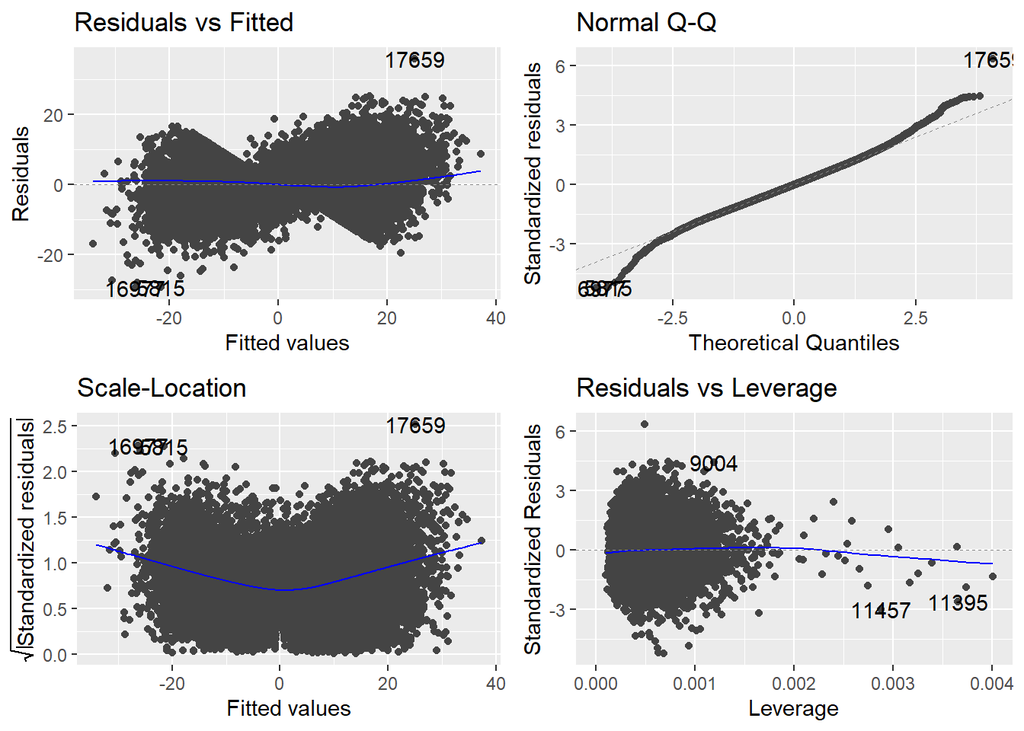

```r
# Diagnostic Plots:

#ceresPlots(step_model)

#ggplot(step_model.diagnostics, aes(win_difference, FG_PCT_home)) + geom_point() + stat_smooth(method = lm, se = FALSE) + geom_segment(aes(xend = win_difference, yend = .fitted), color = "red", size = 0.3)

autoplot( step_model)
```

```r
#plot(step_model, 4)
# Residuals vs Leverage
#plot(step_model, 5)
```

Below we will look at the plots of just the home team stats to get an idea of correlation between the different traits

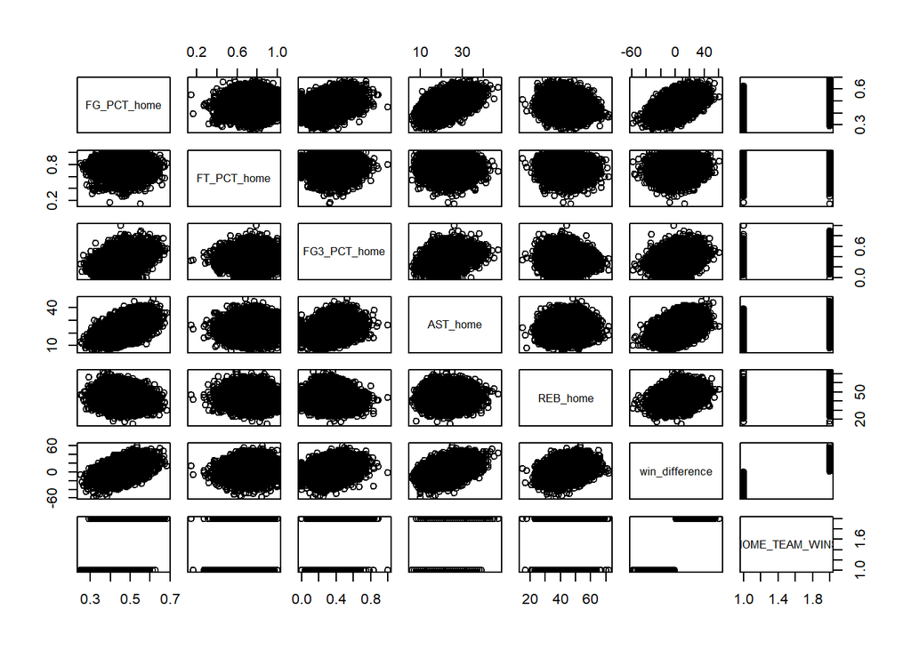

```r
pairs(all_data[c("FG_PCT_home","FT_PCT_home","FG3_PCT_home","AST_home","REB_home","win_difference","HOME_TEAM_WINS")])
```

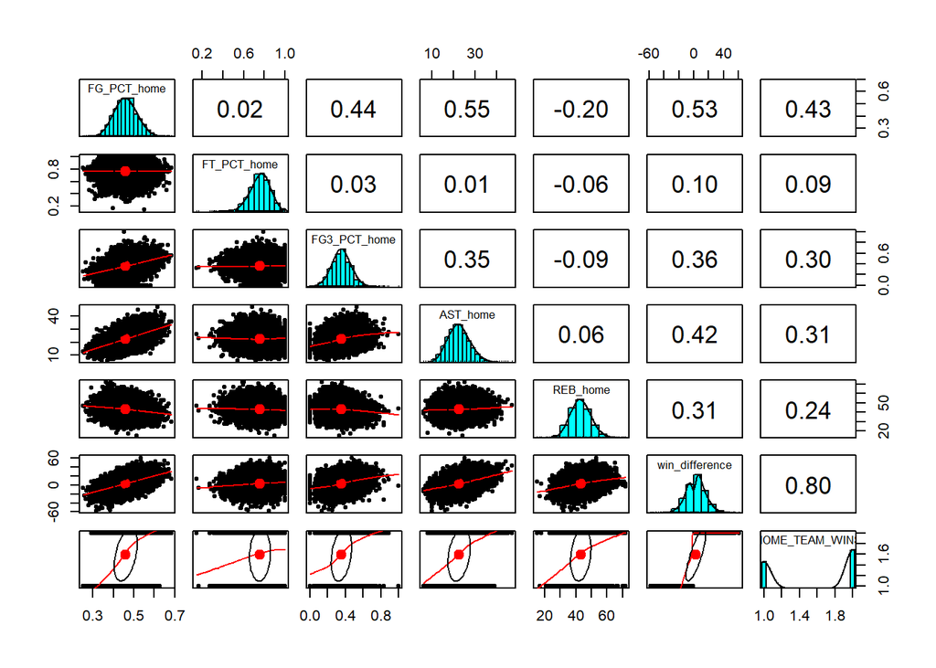

```r
pairs.panels(all_data[c("FG_PCT_home","FT_PCT_home","FG3_PCT_home","AST_home","REB_home","win_difference","HOME_TEAM_WINS")])
```

Here we will try creating new variables (collumns) to see if perhaps there are nonlinear relationships that can improve the model. We will also try converting some numeric variables to binary indicators. We will try introducing the field goal percentage of both home and away as nonlinear terms, and introducing some binary variables.

```r
new_data <- 0 # new data frame to try to create a model from

new_data <- cbind(home_stats, away_stats, win_difference,home_team_wins)

new_data$FG_PCT_home2 <-new_data$FG_PCT_home^2
new_data$FG_PCT_away2 <-new_data$FG_PCT_home^2

new_data$FG50_home <- ifelse(new_data$FG_PCT_home >= .5, 1, 0)
new_data$FG50_away <- ifelse(new_data$FG_PCT_away >= .5, 1, 0)

reg_model_2 <- 0 # testing a new model

reg_model_2 <- lm(win_difference ~ ., data = new_data)
summary (reg_model_2)
```

```
##
## Call:
## lm(formula = win_difference ~ ., data = new_data)
##
## Residuals:
##     Min      1Q  Median      3Q     Max
## -30.109  -3.718  -0.097   3.603  35.892
##
## Coefficients: (1 not defined because of singularities)
##                  Estimate Std. Error t value Pr(>|t|)
## (Intercept)      3.767930   2.113240   1.783 0.074598 .
## FG_PCT_home     25.442589   8.533041   2.982 0.002870 **
## FT_PCT_home      9.415590   0.379343  24.821  < 2e-16 ***
## FG3_PCT_home     9.586584   0.370136  25.900  < 2e-16 ***
## AST_home         0.315126   0.009351  33.700  < 2e-16 ***
## REB_home         0.230020   0.007120  32.307  < 2e-16 ***
## FG_PCT_away    -62.180124   1.208189 -51.466  < 2e-16 ***
## FT_PCT_away    -10.043388   0.369096 -27.211  < 2e-16 ***
## FG3_PCT_away    -9.114845   0.372713 -24.455  < 2e-16 ***
## AST_away        -0.274871   0.009193 -29.901  < 2e-16 ***
## REB_away        -0.227547   0.007143 -31.855  < 2e-16 ***
## home_team_wins  11.058188   0.105361 104.955  < 2e-16 ***
## FG_PCT_home2    33.533789   9.561140   3.507 0.000454 ***
## FG_PCT_away2           NA         NA      NA       NA
## FG50_home       -0.097025   0.147630  -0.657 0.511048
## FG50_away        0.788207   0.133774   5.892 3.87e-09 ***
## ---
## Signif. codes:  0 '***' 0.001 '**' 0.01 '*' 0.05 '.' 0.1 ' ' 1
##
## Residual standard error: 5.657 on 22930 degrees of freedom
##   (99 observations deleted due to missingness)
## Multiple R-squared:  0.8185, Adjusted R-squared:  0.8184
## F-statistic:  7385 on 14 and 22930 DF,  p-value: < 2.2e-16
```

```r
step_model_2 <- MASS::stepAIC(reg_model_2, direction="both", trace=FALSE)
summary (step_model_2)
```

```
##
## Call:
## lm(formula = win_difference ~ FG_PCT_home + FT_PCT_home + FG3_PCT_home +
##     AST_home + REB_home + FG_PCT_away + FT_PCT_away + FG3_PCT_away +
##     AST_away + REB_away + home_team_wins + FG_PCT_home2 + FG50_away,
##     data = new_data)
##
## Residuals:
##     Min      1Q  Median      3Q     Max
## -30.118  -3.718  -0.096   3.599  35.865
##
## Coefficients:
##                  Estimate Std. Error t value Pr(>|t|)
## (Intercept)      3.350856   2.015678   1.662 0.096447 .
## FG_PCT_home     27.715248   7.800866   3.553 0.000382 ***
## FT_PCT_home      9.414668   0.379336  24.819  < 2e-16 ***
## FG3_PCT_home     9.587353   0.370130  25.903  < 2e-16 ***
## AST_home         0.315035   0.009350  33.694  < 2e-16 ***
## REB_home         0.230081   0.007119  32.319  < 2e-16 ***
## FG_PCT_away    -62.187567   1.208121 -51.475  < 2e-16 ***
## FT_PCT_away    -10.041437   0.369080 -27.207  < 2e-16 ***
## FG3_PCT_away    -9.114894   0.372708 -24.456  < 2e-16 ***
## AST_away        -0.274877   0.009193 -29.902  < 2e-16 ***
## REB_away        -0.227476   0.007142 -31.849  < 2e-16 ***
## home_team_wins  11.056699   0.105335 104.967  < 2e-16 ***
## FG_PCT_home2    30.491508   8.365748   3.645 0.000268 ***
## FG50_away        0.788912   0.133768   5.898 3.74e-09 ***
## ---
## Signif. codes:  0 '***' 0.001 '**' 0.01 '*' 0.05 '.' 0.1 ' ' 1
##
## Residual standard error: 5.657 on 22931 degrees of freedom
##   (99 observations deleted due to missingness)
## Multiple R-squared:  0.8185, Adjusted R-squared:  0.8184
## F-statistic:  7953 on 13 and 22931 DF,  p-value: < 2.2e-16
```

Trying to add columns and using AIC again didn’t really improve the model much. The Adjusted R-squared value is now .8184, which is a huge improvement from the first linear regression model we tried which produced an Adjusted R-squared value of 0.496.

SO it looks like a teams efficiency (stats by percentage, rather than absolute points) can give a pretty good estimate of how much the team will win or lose by.